# Final Project 2 - Reproducible Report on COVID19 Data

6/5/2021

## Project Description

COVID-19 or the Coronavirus is a disease caused by SARS-CoV-2 virus. The first known case was identified in Wuhan,China in Dec 2019. This disease is spread all over the world and is currently prevalent in almost all countries.

As part of reproducible report, we will download and analyse COVID-19 data set. There are several websites available for the data set. We will use data set published by Center for Systems Science and Engineering at John Hopkins University. The data is available at github site : https://github.com/CSSEGISandData/COVID-19

## Load Libraries

Load tidyverse and lubridate libraries.

## Download Data

We will download four daily time series data for the Global confirmed cases, US confirmed cases, Global deaths and US deaths. Both Global and US data set has Province/State, Country, Latitude, Longitude and cases or deaths by date.

```r
url_in<-"https://raw.githubusercontent.com/CSSEGISandData/COVID-19/master/csse_covid_19_data/csse_covid_19_time_series/"
file_names<-c("time_series_covid19_confirmed_global.csv",
              "time_series_covid19_deaths_global.csv",
              "time_series_covid19_confirmed_US.csv",
              "time_series_covid19_deaths_US.csv")
urls<-str_c(url_in,file_names)
```

```r
global_cases<-read_csv(urls[1])
global_deaths<-read_csv(urls[2])
US_cases<-read_csv(urls[3])
US_deaths<-read_csv(urls[4])
```

## Review Raw Data

Let’s get glimspe of data from global_cases, global_deaths, US_cases and US_deaths.

```r
head(global_cases)
```

```
## # A tibble: 6 x 505
##   `Province/State` `Country/Region`     Lat   Long `1/22/20` `1/23/20` `1/24/20`
##   <chr>            <chr>              <dbl>  <dbl>     <dbl>     <dbl>     <dbl>
## 1 <NA>             Afghanistan         33.9  67.7          0         0         0
## 2 <NA>             Albania             41.2  20.2          0         0         0
## 3 <NA>             Algeria             28.0   1.66         0         0         0
## 4 <NA>             Andorra             42.5   1.52         0         0         0
## 5 <NA>             Angola             -11.2  17.9          0         0         0
## 6 <NA>             Antigua and Barbu…  17.1 -61.8          0         0         0
## # … with 498 more variables: 1/25/20 <dbl>, 1/26/20 <dbl>, 1/27/20 <dbl>,
## #   1/28/20 <dbl>, 1/29/20 <dbl>, 1/30/20 <dbl>, 1/31/20 <dbl>, 2/1/20 <dbl>,
## #   2/2/20 <dbl>, 2/3/20 <dbl>, 2/4/20 <dbl>, 2/5/20 <dbl>, 2/6/20 <dbl>,
## #   2/7/20 <dbl>, 2/8/20 <dbl>, 2/9/20 <dbl>, 2/10/20 <dbl>, 2/11/20 <dbl>,
## #   2/12/20 <dbl>, 2/13/20 <dbl>, 2/14/20 <dbl>, 2/15/20 <dbl>, 2/16/20 <dbl>,
## #   2/17/20 <dbl>, 2/18/20 <dbl>, 2/19/20 <dbl>, 2/20/20 <dbl>, 2/21/20 <dbl>,
## #   2/22/20 <dbl>, 2/23/20 <dbl>, 2/24/20 <dbl>, 2/25/20 <dbl>, 2/26/20 <dbl>,
## #   2/27/20 <dbl>, 2/28/20 <dbl>, 2/29/20 <dbl>, 3/1/20 <dbl>, 3/2/20 <dbl>,
## #   3/3/20 <dbl>, 3/4/20 <dbl>, 3/5/20 <dbl>, 3/6/20 <dbl>, 3/7/20 <dbl>,
## #   3/8/20 <dbl>, 3/9/20 <dbl>, 3/10/20 <dbl>, 3/11/20 <dbl>, 3/12/20 <dbl>,
## #   3/13/20 <dbl>, 3/14/20 <dbl>, 3/15/20 <dbl>, 3/16/20 <dbl>, 3/17/20 <dbl>,
## #   3/18/20 <dbl>, 3/19/20 <dbl>, 3/20/20 <dbl>, 3/21/20 <dbl>, 3/22/20 <dbl>,
## #   3/23/20 <dbl>, 3/24/20 <dbl>, 3/25/20 <dbl>, 3/26/20 <dbl>, 3/27/20 <dbl>,
## #   3/28/20 <dbl>, 3/29/20 <dbl>, 3/30/20 <dbl>, 3/31/20 <dbl>, 4/1/20 <dbl>,
## #   4/2/20 <dbl>, 4/3/20 <dbl>, 4/4/20 <dbl>, 4/5/20 <dbl>, 4/6/20 <dbl>,
## #   4/7/20 <dbl>, 4/8/20 <dbl>, 4/9/20 <dbl>, 4/10/20 <dbl>, 4/11/20 <dbl>,
## #   4/12/20 <dbl>, 4/13/20 <dbl>, 4/14/20 <dbl>, 4/15/20 <dbl>, 4/16/20 <dbl>,
## #   4/17/20 <dbl>, 4/18/20 <dbl>, 4/19/20 <dbl>, 4/20/20 <dbl>, 4/21/20 <dbl>,
## #   4/22/20 <dbl>, 4/23/20 <dbl>, 4/24/20 <dbl>, 4/25/20 <dbl>, 4/26/20 <dbl>,
## #   4/27/20 <dbl>, 4/28/20 <dbl>, 4/29/20 <dbl>, 4/30/20 <dbl>, 5/1/20 <dbl>,
## #   5/2/20 <dbl>, 5/3/20 <dbl>, …
```

```r
head(global_deaths)
```

```
## # A tibble: 6 x 505
##   `Province/State` `Country/Region`     Lat   Long `1/22/20` `1/23/20` `1/24/20`
##   <chr>            <chr>              <dbl>  <dbl>     <dbl>     <dbl>     <dbl>
## 1 <NA>             Afghanistan         33.9  67.7          0         0         0
## 2 <NA>             Albania             41.2  20.2          0         0         0
## 3 <NA>             Algeria             28.0   1.66         0         0         0
## 4 <NA>             Andorra             42.5   1.52         0         0         0
## 5 <NA>             Angola             -11.2  17.9          0         0         0
## 6 <NA>             Antigua and Barbu…  17.1 -61.8          0         0         0
## # … with 498 more variables: 1/25/20 <dbl>, 1/26/20 <dbl>, 1/27/20 <dbl>,
## #   1/28/20 <dbl>, 1/29/20 <dbl>, 1/30/20 <dbl>, 1/31/20 <dbl>, 2/1/20 <dbl>,
## #   2/2/20 <dbl>, 2/3/20 <dbl>, 2/4/20 <dbl>, 2/5/20 <dbl>, 2/6/20 <dbl>,
## #   2/7/20 <dbl>, 2/8/20 <dbl>, 2/9/20 <dbl>, 2/10/20 <dbl>, 2/11/20 <dbl>,
## #   2/12/20 <dbl>, 2/13/20 <dbl>, 2/14/20 <dbl>, 2/15/20 <dbl>, 2/16/20 <dbl>,
## #   2/17/20 <dbl>, 2/18/20 <dbl>, 2/19/20 <dbl>, 2/20/20 <dbl>, 2/21/20 <dbl>,
## #   2/22/20 <dbl>, 2/23/20 <dbl>, 2/24/20 <dbl>, 2/25/20 <dbl>, 2/26/20 <dbl>,
## #   2/27/20 <dbl>, 2/28/20 <dbl>, 2/29/20 <dbl>, 3/1/20 <dbl>, 3/2/20 <dbl>,
## #   3/3/20 <dbl>, 3/4/20 <dbl>, 3/5/20 <dbl>, 3/6/20 <dbl>, 3/7/20 <dbl>,
## #   3/8/20 <dbl>, 3/9/20 <dbl>, 3/10/20 <dbl>, 3/11/20 <dbl>, 3/12/20 <dbl>,
## #   3/13/20 <dbl>, 3/14/20 <dbl>, 3/15/20 <dbl>, 3/16/20 <dbl>, 3/17/20 <dbl>,
## #   3/18/20 <dbl>, 3/19/20 <dbl>, 3/20/20 <dbl>, 3/21/20 <dbl>, 3/22/20 <dbl>,
## #   3/23/20 <dbl>, 3/24/20 <dbl>, 3/25/20 <dbl>, 3/26/20 <dbl>, 3/27/20 <dbl>,
## #   3/28/20 <dbl>, 3/29/20 <dbl>, 3/30/20 <dbl>, 3/31/20 <dbl>, 4/1/20 <dbl>,
## #   4/2/20 <dbl>, 4/3/20 <dbl>, 4/4/20 <dbl>, 4/5/20 <dbl>, 4/6/20 <dbl>,
## #   4/7/20 <dbl>, 4/8/20 <dbl>, 4/9/20 <dbl>, 4/10/20 <dbl>, 4/11/20 <dbl>,
## #   4/12/20 <dbl>, 4/13/20 <dbl>, 4/14/20 <dbl>, 4/15/20 <dbl>, 4/16/20 <dbl>,
## #   4/17/20 <dbl>, 4/18/20 <dbl>, 4/19/20 <dbl>, 4/20/20 <dbl>, 4/21/20 <dbl>,
## #   4/22/20 <dbl>, 4/23/20 <dbl>, 4/24/20 <dbl>, 4/25/20 <dbl>, 4/26/20 <dbl>,
## #   4/27/20 <dbl>, 4/28/20 <dbl>, 4/29/20 <dbl>, 4/30/20 <dbl>, 5/1/20 <dbl>,
## #   5/2/20 <dbl>, 5/3/20 <dbl>, …
```

```r
head(US_cases)
```

```
## # A tibble: 6 x 512
##        UID iso2  iso3  code3  FIPS Admin2  Province_State Country_Region   Lat
##      <dbl> <chr> <chr> <dbl> <dbl> <chr>   <chr>          <chr>          <dbl>
## 1 84001001 US    USA     840  1001 Autauga Alabama        US              32.5
## 2 84001003 US    USA     840  1003 Baldwin Alabama        US              30.7
## 3 84001005 US    USA     840  1005 Barbour Alabama        US              31.9
## 4 84001007 US    USA     840  1007 Bibb    Alabama        US              33.0
## 5 84001009 US    USA     840  1009 Blount  Alabama        US              34.0
## 6 84001011 US    USA     840  1011 Bullock Alabama        US              32.1
## # … with 503 more variables: Long_ <dbl>, Combined_Key <chr>, 1/22/20 <dbl>,
## #   1/23/20 <dbl>, 1/24/20 <dbl>, 1/25/20 <dbl>, 1/26/20 <dbl>, 1/27/20 <dbl>,
## #   1/28/20 <dbl>, 1/29/20 <dbl>, 1/30/20 <dbl>, 1/31/20 <dbl>, 2/1/20 <dbl>,
## #   2/2/20 <dbl>, 2/3/20 <dbl>, 2/4/20 <dbl>, 2/5/20 <dbl>, 2/6/20 <dbl>,
## #   2/7/20 <dbl>, 2/8/20 <dbl>, 2/9/20 <dbl>, 2/10/20 <dbl>, 2/11/20 <dbl>,
## #   2/12/20 <dbl>, 2/13/20 <dbl>, 2/14/20 <dbl>, 2/15/20 <dbl>, 2/16/20 <dbl>,
## #   2/17/20 <dbl>, 2/18/20 <dbl>, 2/19/20 <dbl>, 2/20/20 <dbl>, 2/21/20 <dbl>,
## #   2/22/20 <dbl>, 2/23/20 <dbl>, 2/24/20 <dbl>, 2/25/20 <dbl>, 2/26/20 <dbl>,
## #   2/27/20 <dbl>, 2/28/20 <dbl>, 2/29/20 <dbl>, 3/1/20 <dbl>, 3/2/20 <dbl>,
## #   3/3/20 <dbl>, 3/4/20 <dbl>, 3/5/20 <dbl>, 3/6/20 <dbl>, 3/7/20 <dbl>,
## #   3/8/20 <dbl>, 3/9/20 <dbl>, 3/10/20 <dbl>, 3/11/20 <dbl>, 3/12/20 <dbl>,
## #   3/13/20 <dbl>, 3/14/20 <dbl>, 3/15/20 <dbl>, 3/16/20 <dbl>, 3/17/20 <dbl>,
## #   3/18/20 <dbl>, 3/19/20 <dbl>, 3/20/20 <dbl>, 3/21/20 <dbl>, 3/22/20 <dbl>,
## #   3/23/20 <dbl>, 3/24/20 <dbl>, 3/25/20 <dbl>, 3/26/20 <dbl>, 3/27/20 <dbl>,
## #   3/28/20 <dbl>, 3/29/20 <dbl>, 3/30/20 <dbl>, 3/31/20 <dbl>, 4/1/20 <dbl>,
## #   4/2/20 <dbl>, 4/3/20 <dbl>, 4/4/20 <dbl>, 4/5/20 <dbl>, 4/6/20 <dbl>,
## #   4/7/20 <dbl>, 4/8/20 <dbl>, 4/9/20 <dbl>, 4/10/20 <dbl>, 4/11/20 <dbl>,
## #   4/12/20 <dbl>, 4/13/20 <dbl>, 4/14/20 <dbl>, 4/15/20 <dbl>, 4/16/20 <dbl>,
## #   4/17/20 <dbl>, 4/18/20 <dbl>, 4/19/20 <dbl>, 4/20/20 <dbl>, 4/21/20 <dbl>,
## #   4/22/20 <dbl>, 4/23/20 <dbl>, 4/24/20 <dbl>, 4/25/20 <dbl>, 4/26/20 <dbl>,
## #   4/27/20 <dbl>, 4/28/20 <dbl>, …
```

```r
head(US_deaths)
```

```
## # A tibble: 6 x 513
##        UID iso2  iso3  code3  FIPS Admin2  Province_State Country_Region   Lat
##      <dbl> <chr> <chr> <dbl> <dbl> <chr>   <chr>          <chr>          <dbl>
## 1 84001001 US    USA     840  1001 Autauga Alabama        US              32.5
## 2 84001003 US    USA     840  1003 Baldwin Alabama        US              30.7
## 3 84001005 US    USA     840  1005 Barbour Alabama        US              31.9
## 4 84001007 US    USA     840  1007 Bibb    Alabama        US              33.0
## 5 84001009 US    USA     840  1009 Blount  Alabama        US              34.0
## 6 84001011 US    USA     840  1011 Bullock Alabama        US              32.1
## # … with 504 more variables: Long_ <dbl>, Combined_Key <chr>, Population <dbl>,
## #   1/22/20 <dbl>, 1/23/20 <dbl>, 1/24/20 <dbl>, 1/25/20 <dbl>, 1/26/20 <dbl>,
## #   1/27/20 <dbl>, 1/28/20 <dbl>, 1/29/20 <dbl>, 1/30/20 <dbl>, 1/31/20 <dbl>,
## #   2/1/20 <dbl>, 2/2/20 <dbl>, 2/3/20 <dbl>, 2/4/20 <dbl>, 2/5/20 <dbl>,
## #   2/6/20 <dbl>, 2/7/20 <dbl>, 2/8/20 <dbl>, 2/9/20 <dbl>, 2/10/20 <dbl>,
## #   2/11/20 <dbl>, 2/12/20 <dbl>, 2/13/20 <dbl>, 2/14/20 <dbl>, 2/15/20 <dbl>,
## #   2/16/20 <dbl>, 2/17/20 <dbl>, 2/18/20 <dbl>, 2/19/20 <dbl>, 2/20/20 <dbl>,
## #   2/21/20 <dbl>, 2/22/20 <dbl>, 2/23/20 <dbl>, 2/24/20 <dbl>, 2/25/20 <dbl>,
## #   2/26/20 <dbl>, 2/27/20 <dbl>, 2/28/20 <dbl>, 2/29/20 <dbl>, 3/1/20 <dbl>,
## #   3/2/20 <dbl>, 3/3/20 <dbl>, 3/4/20 <dbl>, 3/5/20 <dbl>, 3/6/20 <dbl>,
## #   3/7/20 <dbl>, 3/8/20 <dbl>, 3/9/20 <dbl>, 3/10/20 <dbl>, 3/11/20 <dbl>,
## #   3/12/20 <dbl>, 3/13/20 <dbl>, 3/14/20 <dbl>, 3/15/20 <dbl>, 3/16/20 <dbl>,
## #   3/17/20 <dbl>, 3/18/20 <dbl>, 3/19/20 <dbl>, 3/20/20 <dbl>, 3/21/20 <dbl>,
## #   3/22/20 <dbl>, 3/23/20 <dbl>, 3/24/20 <dbl>, 3/25/20 <dbl>, 3/26/20 <dbl>,
## #   3/27/20 <dbl>, 3/28/20 <dbl>, 3/29/20 <dbl>, 3/30/20 <dbl>, 3/31/20 <dbl>,
## #   4/1/20 <dbl>, 4/2/20 <dbl>, 4/3/20 <dbl>, 4/4/20 <dbl>, 4/5/20 <dbl>,
## #   4/6/20 <dbl>, 4/7/20 <dbl>, 4/8/20 <dbl>, 4/9/20 <dbl>, 4/10/20 <dbl>,
## #   4/11/20 <dbl>, 4/12/20 <dbl>, 4/13/20 <dbl>, 4/14/20 <dbl>, 4/15/20 <dbl>,
## #   4/16/20 <dbl>, 4/17/20 <dbl>, 4/18/20 <dbl>, 4/19/20 <dbl>, 4/20/20 <dbl>,
## #   4/21/20 <dbl>, 4/22/20 <dbl>, 4/23/20 <dbl>, 4/24/20 <dbl>, 4/25/20 <dbl>,
## #   4/26/20 <dbl>, 4/27/20 <dbl>, …
```

Raw data in all four data sets have each data as column. Also there are some nulls values in Province/State column in global_cases and global_deaths data set. US Data set has additional columns e.g UID, iso2, iso3,code3 etc.

## Cleaning and Processing

### Global Cases and Deaths Data Set

Both Global cases and Global death dataset has ‘Province/State’, ‘Country/Region’, ‘Lat’, ‘Long’ and data by dates. We will remove ‘Lat’ and ‘Long’ as we will not be using this for data analysis. Also we will move data columns to rows i.e we will have each date in separate rows using pivot_longer method. We will also join cases and death dataset into ‘global’ dataset.

```r
global_cases<-global_cases %>%
  pivot_longer(cols = -c('Province/State','Country/Region',Lat,Long),names_to="date",values_to="cases") %>% select(-c(Lat,Long))
global_deaths<-global_deaths %>%
  pivot_longer(cols = -c('Province/State','Country/Region',Lat,Long),names_to="date",values_to="deaths") %>% select(-c(Lat,Long))
global <- global_cases %>% full_join(global_deaths) %>% rename(Country_Region ='Country/Region',Province_State ='Province/State') %>%
  mutate(date= mdy(date))
```

Below is the output of global dataset post tidying and joining global_cases and global_deaths datasets.

```r
head(global)
```

```
## # A tibble: 6 x 5
##   Province_State Country_Region date       cases deaths
##   <chr>          <chr>          <date>     <dbl>  <dbl>
## 1 <NA>           Afghanistan    2020-01-22     0      0
## 2 <NA>           Afghanistan    2020-01-23     0      0
## 3 <NA>           Afghanistan    2020-01-24     0      0
## 4 <NA>           Afghanistan    2020-01-25     0      0
## 5 <NA>           Afghanistan    2020-01-26     0      0
## 6 <NA>           Afghanistan    2020-01-27     0      0
```

Lets summarize the global dataset. We see the earliset case is on 22nd January 2020. Min cases and deaths is zero. There may be possibility of several records with zero cases/deaths.

```r
summary(global)
```

```
##  Province_State     Country_Region          date                cases
##  Length:138276      Length:138276      Min.   :2020-01-22   Min.   :       0
##  Class :character   Class :character   1st Qu.:2020-05-26   1st Qu.:      93
##  Mode  :character   Mode  :character   Median :2020-09-28   Median :    1424
##                                        Mean   :2020-09-28   Mean   :  198538
##                                        3rd Qu.:2021-01-31   3rd Qu.:   30361
##                                        Max.   :2021-06-05   Max.   :33357205
##      deaths
##  Min.   :     0
##  1st Qu.:     1
##  Median :    22
##  Mean   :  4698
##  3rd Qu.:   531
##  Max.   :597377
```

We will filter null cases from global dataset, i.e we will consider only positive cases. Below is the summary after removing null cases.

```r
#Filter only cases which are positive
global <-global %>% filter(cases >0)
summary(global)
```

```
##  Province_State     Country_Region          date                cases
##  Length:123978      Length:123978      Min.   :2020-01-22   Min.   :       1
##  Class :character   Class :character   1st Qu.:2020-06-25   1st Qu.:     260
##  Mode  :character   Mode  :character   Median :2020-10-21   Median :    2526
##                                        Mean   :2020-10-18   Mean   :  221435
##                                        3rd Qu.:2021-02-12   3rd Qu.:   44416
##                                        Max.   :2021-06-05   Max.   :33357205
##      deaths
##  Min.   :     0.0
##  1st Qu.:     2.0
##  Median :    45.5
##  Mean   :  5239.6
##  3rd Qu.:   752.0
##  Max.   :597377.0
```

### US Cases and Deaths Data Set

We will follow similar process for US Cases and Deaths dataset. We will clean data and join into ‘US’ dataset. This dataset has UID, iso2,iso3,code3,FIPS,Admin2,Province_State, Country_Regon, Lat,Long, Combined_Key and dates. Also date is a character instead of date object. US deaths has population data. We will combined these datasets into ‘US’ .

```r
US_cases<-US_cases %>%pivot_longer(cols=-(UID:Combined_Key),names_to="date",values_to="cases") %>% select(Admin2:cases)%>% mutate(date=mdy(date))%>%select(-c(Lat,Long_))
US_deaths<-US_deaths %>%pivot_longer(cols=-(UID:Population),names_to="date",values_to="deaths") %>% select(Admin2:deaths)%>% mutate(date=mdy(date))%>%select(-c(Lat,Long_))
US <- US_cases %>% full_join(US_deaths)
head(US)
```

```
## # A tibble: 6 x 8
##   Admin2  Province_State Country_Region Combined_Key date       cases Population
##   <chr>   <chr>          <chr>          <chr>        <date>     <dbl>      <dbl>
## 1 Autauga Alabama        US             Autauga, Al… 2020-01-22     0      55869
## 2 Autauga Alabama        US             Autauga, Al… 2020-01-23     0      55869
## 3 Autauga Alabama        US             Autauga, Al… 2020-01-24     0      55869
## 4 Autauga Alabama        US             Autauga, Al… 2020-01-25     0      55869
## 5 Autauga Alabama        US             Autauga, Al… 2020-01-26     0      55869
## 6 Autauga Alabama        US             Autauga, Al… 2020-01-27     0      55869
## # … with 1 more variable: deaths <dbl>
```

###World Population Data We have US population data, but we dont have world population data in global dataset. This information is useful to comparative analysis between countries. Lets add population data and variable called combined_key into ‘global’ dataset. We will download global population data from https://github.com/CSSEGISandData/COVID-19/tree/master/csse_covid_19_data from file UID_ISO_FIPS_LookUp_Table.csv. We will add population data to ‘global’ data set by joining based on Province_State and Country_Region.

```r
global<- global %>% unite("Combined_Key",c(Province_State,Country_Region),sep=", ",na.rm=TRUE,remove=FALSE)
uid_lookup_url<-"https://raw.githubusercontent.com/CSSEGISandData/COVID-19/master/csse_covid_19_data/UID_ISO_FIPS_LookUp_Table.csv"
uid<-read_csv(uid_lookup_url) %>% select(-c(Lat,Long_,Combined_Key,code3,iso2,iso3,Admin2))
global <- global %>%
  left_join(uid,by=c("Province_State","Country_Region")) %>%
  select(-c(UID,FIPS)) %>%
  select(Province_State,Country_Region,date,cases,deaths,Population,Combined_Key)
```

## Data Vizualization

###Covid Cases, Deaths by US and by US States (New York and Alaska) Lets analyse data of United States as a whole and for a given state. We will first group the data by Province_State, Country_Region and date and summarize the data by number of cases,deaths and Population. We will compute covid-19 deaths per million and add under column ‘deaths_per_mill’.

```r
US_by_state <- US %>% group_by(Province_State,Country_Region,date) %>%
  summarise(cases=sum(cases),deaths=sum(deaths),Population=sum(Population)) %>%
  mutate(deaths_per_mill =deaths*1000000/Population)%>%
  select(Province_State,Country_Region,date,cases,deaths,deaths_per_mill,Population)%>%
  ungroup()
head(US_by_state)
```

```
## # A tibble: 6 x 7
##   Province_State Country_Region date       cases deaths deaths_per_mill
##   <chr>          <chr>          <date>     <dbl>  <dbl>           <dbl>
## 1 Alabama        US             2020-01-22     0      0               0
## 2 Alabama        US             2020-01-23     0      0               0
## 3 Alabama        US             2020-01-24     0      0               0
## 4 Alabama        US             2020-01-25     0      0               0
## 5 Alabama        US             2020-01-26     0      0               0
## 6 Alabama        US             2020-01-27     0      0               0
## # … with 1 more variable: Population <dbl>
```

Get the US total deaths by summarizing US_by_state data set.

```r
US_totals <- US_by_state %>% group_by(Country_Region,date) %>%
  summarise(cases=sum(cases),deaths=sum(deaths),Population=sum(Population)) %>%
  mutate(deaths_per_mill =deaths*1000000/Population) %>%
  select(Country_Region,date,cases,deaths,deaths_per_mill,Population)%>%
  ungroup()
head(US_totals)
```

```
## # A tibble: 6 x 6
##   Country_Region date       cases deaths deaths_per_mill Population
##   <chr>          <date>     <dbl>  <dbl>           <dbl>      <dbl>
## 1 US             2020-01-22     1      1         0.00300  332875137
## 2 US             2020-01-23     1      1         0.00300  332875137
## 3 US             2020-01-24     2      1         0.00300  332875137
## 4 US             2020-01-25     2      1         0.00300  332875137
## 5 US             2020-01-26     5      1         0.00300  332875137
## 6 US             2020-01-27     5      1         0.00300  332875137
```

Below visualization shows the cases and deaths trend in the United States from the start of the reporting of the COVID-19.

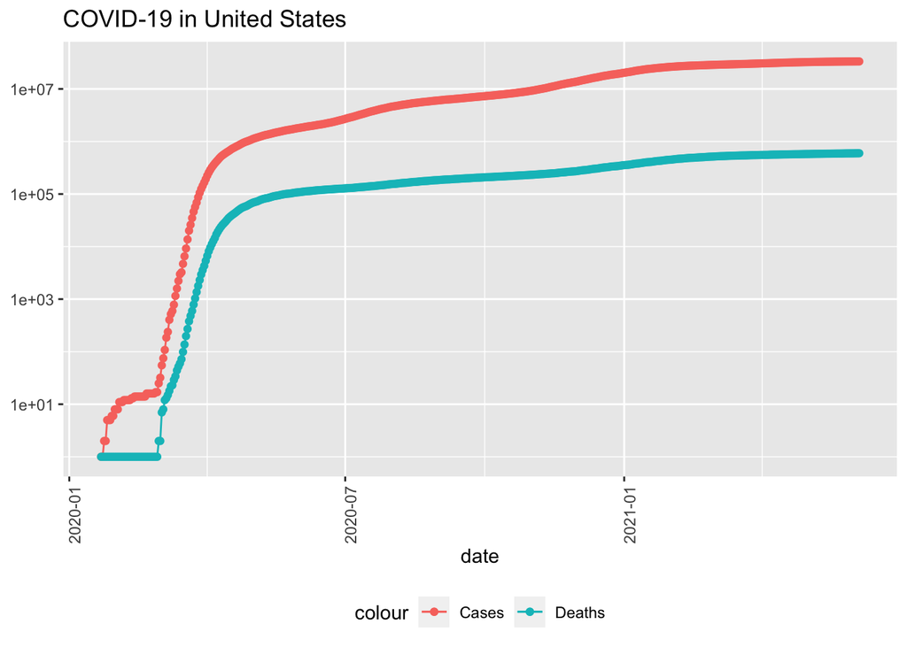

```r
US_totals%>%
  filter(cases>0) %>%
  ggplot(aes(x=date,y=cases))+
  geom_line(aes(color="Cases"))+
  geom_point(aes(color="Cases"))+
  geom_line(aes(y=deaths,color="Deaths"))+
  geom_point(aes(y=deaths,color="Deaths"))+
  scale_y_log10()+
  theme(legend.position = "bottom",axis.text.x=element_text(angle=90))+
  labs(title="COVID-19 in United States",y=NULL)
```

Lets visualize cases, and deaths trend by state. We will analyse the trend in New York and Alaska.

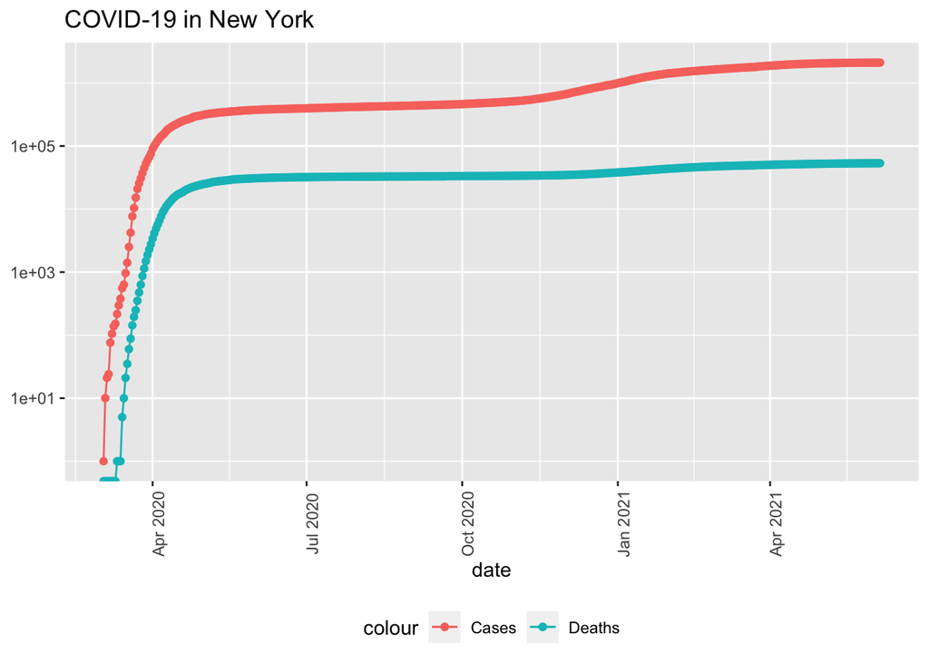

```r
state1<-"New York"
US_by_state%>%
  filter(Province_State == state1) %>%
  filter(cases>0) %>%
  ggplot(aes(x=date,y=cases))+
  geom_line(aes(color="Cases"))+
  geom_point(aes(color="Cases"))+
  geom_line(aes(y=deaths,color="Deaths"))+
  geom_point(aes(y=deaths,color="Deaths"))+
  scale_y_log10()+
  theme(legend.position = "bottom",axis.text.x=element_text(angle=90))+
  labs(title=str_c("COVID-19 in ",state1),y=NULL)
```

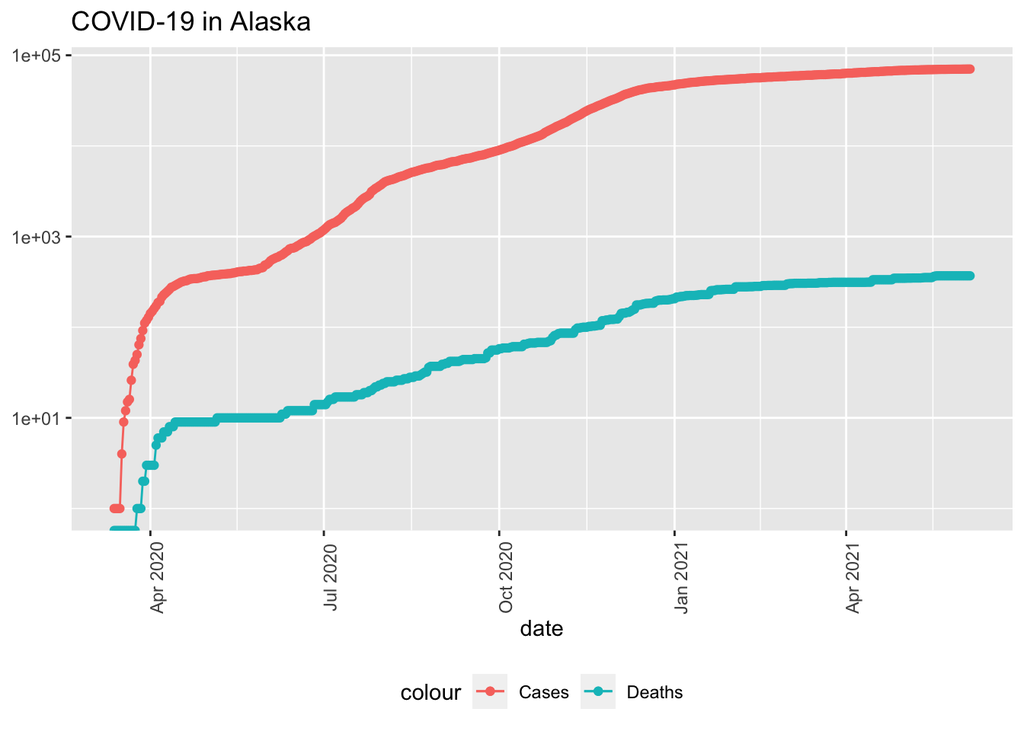

```r
state2<-"Alaska"
US_by_state%>%
  filter(Province_State == state2) %>%
  filter(cases>0) %>%
  ggplot(aes(x=date,y=cases))+
  geom_line(aes(color="Cases"))+
  geom_point(aes(color="Cases"))+
  geom_line(aes(y=deaths,color="Deaths"))+
  geom_point(aes(y=deaths,color="Deaths"))+
  scale_y_log10()+
  theme(legend.position = "bottom",axis.text.x=element_text(angle=90))+
  labs(title=str_c("COVID-19 in ",state2),y=NULL)
```

The visualization for both US and states shows that the cases peaked initially and levelled off from Jan 2021 onwards. We will deep dive on the new cases and check if the cases have really leveled off. In our data set we will add two column : new_cases and new_deaths. Below trend shows that the cases are dropping in both US and New York from Jan 2021 onwards. This may be due to Vaccinnation drive by both Federal and State goverments.

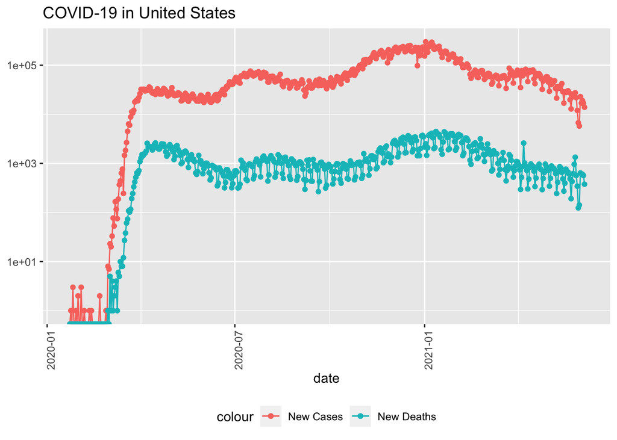

```r
US_by_state <- US_by_state %>% mutate(new_cases=cases-lag(cases),new_deaths=deaths-lag(deaths))
US_totals <- US_totals %>% mutate(new_cases=cases-lag(cases),new_deaths=deaths-lag(deaths))

US_totals%>%
  ggplot(aes(x=date,y=new_cases))+
  geom_line(aes(color="New Cases"))+
  geom_point(aes(color="New Cases"))+
  geom_line(aes(y=new_deaths,color="New Deaths"))+
  geom_point(aes(y=new_deaths,color="New Deaths"))+
  scale_y_log10()+
  theme(legend.position = "bottom",axis.text.x=element_text(angle=90))+
  labs(title="COVID-19 in United States",y=NULL)
```

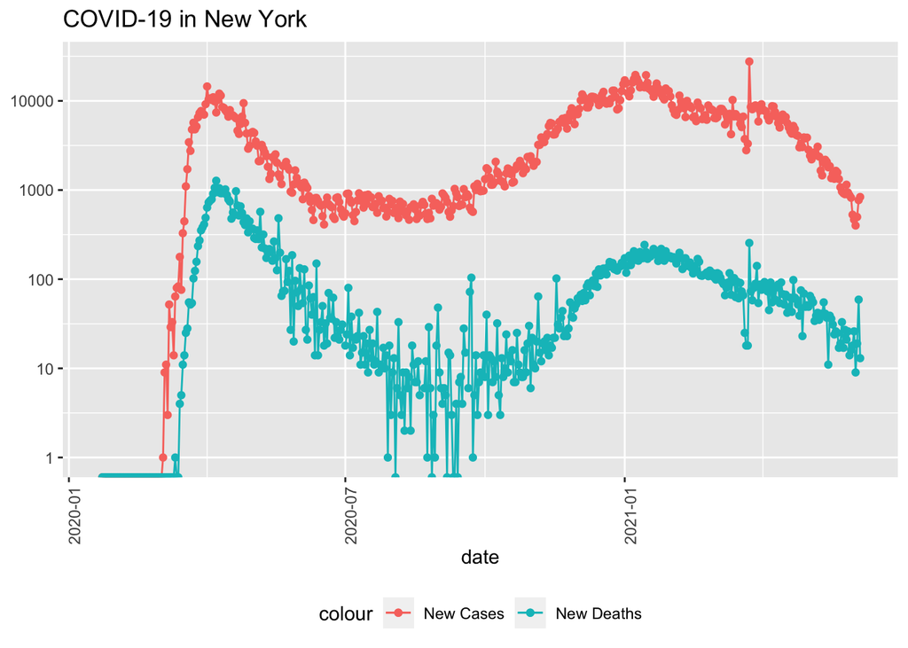

```r
state1<-"New York"
US_by_state%>%
  filter(Province_State == state1) %>%
  ggplot(aes(x=date,y=new_cases))+
  geom_line(aes(color="New Cases"))+
  geom_point(aes(color="New Cases"))+
  geom_line(aes(y=new_deaths,color="New Deaths"))+
  geom_point(aes(y=new_deaths,color="New Deaths"))+
  scale_y_log10()+
  theme(legend.position = "bottom",axis.text.x=element_text(angle=90))+
  labs(title=str_c("COVID-19 in ",state1),y=NULL)
```

Which are the top 10 states with low cases and deaths? Lets compute cases and deaths per thousands by each state. We will filter out data where the cases and population is zero.

```r
US_state_totals <-US_by_state %>%
  group_by(Province_State) %>%
  summarise(deaths=max(deaths),cases=max(cases),
            population=max(Population),
            cases_per_thou=1000*cases/population,
            deaths_per_thou=1000*deaths/population) %>%
  filter(cases >0, population>0)
US_state_totals %>%slice_min(deaths_per_thou,n=10)
```

```
## # A tibble: 10 x 6
##    Province_State        deaths  cases population cases_per_thou deaths_per_thou
##    <chr>                  <dbl>  <dbl>      <dbl>          <dbl>           <dbl>
##  1 Northern Mariana Isl…      2    183      55144           3.32          0.0363
##  2 Virgin Islands            28   3512     107268          32.7           0.261
##  3 Hawaii                   502  36535    1415872          25.8           0.355
##  4 Vermont                  256  24252     623989          38.9           0.410
##  5 Alaska                   369  70469     740995          95.1           0.498
##  6 Maine                    839  68155    1344212          50.7           0.624
##  7 Oregon                  2691 202995    4217737          48.1           0.638
##  8 Puerto Rico             2518 139004    3754939          37.0           0.671
##  9 Utah                    2311 407419    3205958         127.            0.721
## 10 Washington              5836 440057    7614893          57.8           0.766
```

```r
US_state_totals %>%slice_max(deaths_per_thou,n=10)
```

```
## # A tibble: 10 x 6
##    Province_State deaths   cases population cases_per_thou deaths_per_thou
##    <chr>           <dbl>   <dbl>      <dbl>          <dbl>           <dbl>
##  1 New Jersey      26273 1017695    8882190          115.             2.96
##  2 New York        53429 2105375   19453561          108.             2.75
##  3 Massachusetts   17907  707940    6892503          103.             2.60
##  4 Rhode Island     2717  151992    1059361          143.             2.56
##  5 Mississippi      7325  318189    2976149          107.             2.46
##  6 Arizona         17698  883314    7278717          121.             2.43
##  7 Connecticut      8247  347891    3565287           97.6            2.31
##  8 South Dakota     2022  124261     884659          140.             2.29
##  9 Alabama         11198  545585    4903185          111.             2.28
## 10 Louisiana       10615  472981    4648794          102.             2.28
```

## Modelling

We will use linear model and understand the relationship between deaths and number of cases. We will look at deaths per thousands as function of cases per thousand. After creating linear model , we will add pred column to US State Totals dataset. ‘Pred’ is the predicted value based on the linear model.

```r
mod<-lm(deaths_per_thou~cases_per_thou,data=US_state_totals)
US_tot_w_pred<-US_state_totals%>% mutate(pred=predict(mod))
head(US_tot_w_pred)
```

```
## # A tibble: 6 x 7
##   Province_State deaths   cases population cases_per_thou deaths_per_thou  pred
##   <chr>           <dbl>   <dbl>      <dbl>          <dbl>           <dbl> <dbl>
## 1 Alabama         11198  545585    4903185          111.            2.28   1.85
## 2 Alaska            369   70469     740995           95.1           0.498  1.58
## 3 Arizona         17698  883314    7278717          121.            2.43   2.02
## 4 Arkansas         5846  342345    3017804          113.            1.94   1.89
## 5 California      63441 3794927   39512223           96.0           1.61   1.60
## 6 Colorado         6613  546500    5758736           94.9           1.15   1.58
```

Now lets plot based on the actual and predicted values to see how well the model is doing. Red is our prediciton and blue dots are actual values. THe model seems to be doing ok, but there are some outliers.

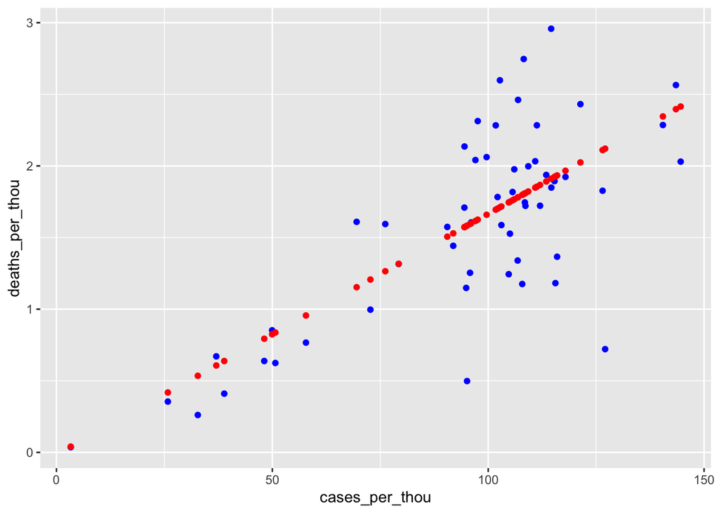

```r
US_tot_w_pred%>%ggplot()+geom_point(aes(x=cases_per_thou,y=deaths_per_thou),color="blue")+geom_point(aes(x=cases_per_thou,y=pred),color="red")
```

## Analysis of Bias

Covid-19 data is collected from various sources. Counting exact number of cases is difficult as the data is collected from government agencies, private hospitals, Non-governmental agencies. There is also time lag in the collection of data because covid causes some mild illness in people and it takes some time for symptoms to appear. Also not everyone who gets infected gets tested. Again this depends on countries, states, provinces.